# Wikipedia Pageviews as a Measure of Attention

A year of Wikipedia pageviews, and what a country looking something up does not tell you

Democracy’s Data

Last updated September 13, 2026 at 10:53a EDT

On 14 July 2024, 91,621 people opened J.D. Vance’s Wikipedia article. On 15 July, 5,120,129 did. That is the largest single article-day anywhere in this file, larger even than the presidential election article on the day after the election. Nothing about the man had changed overnight, and nothing about the article had either. Somebody put his name on a ticket,[^1] and a country that had not been wondering who he was suddenly wanted to know.

Attention is the resource campaigns compete for, and everyone asserts that it is scarce and lopsided. That is a claim about the country, and it can be checked. So turn it into a question: **who does the public actually go looking for during a campaign year, and does the answer look anything like who matters?**

The answer turns out to be sharp in both directions. Attention is savagely concentrated in time, and the people it lands on hardest are the ones nobody had heard of.

## The test

The measure is Wikipedia pageviews. A **pageview** is one request for one article, counted by the Wikimedia Foundation’s servers as they answer it, and the file holds the daily count of them for each of twelve English Wikipedia articles, every day of 2024, with the traffic the Foundation can identify as automated left out. The Foundation publishes these counts for every article, free, with no key needed, and places them in the public domain under a CC0 dedication (https://wikimedia.org/api/rest_v1/#/Pageviews%20data).[^2]

Why a pageview log, of all sources? Nobody at Wikimedia decided that American politics should be measured. These counts are the by-product of running a very large website, tallied because a server tallies what it serves, and they would look much the same if there had been no election. That makes them an administrative record rather than a survey, which is the kind of file this section of the book is about.

The advantage is specific. A survey question about media use depends on somebody remembering accurately and answering honestly. **A pageview is one person choosing to look something up**, and looking is an act, so it can be counted rather than recalled. The count is also daily and continuous, which gives a spike something to be a spike against. No survey in the United States is fielded every day, and none was in the field on the July afternoon this brief turns on.

## The data

One row is one article on one day. Here is one of them, from a day worth knowing: 22 July 2024 was the day after Joe Biden withdrew from the race and endorsed Kamala Harris, whose article this is.[^3]

| Field | Value | What it is |
| --- | --- | --- |
| date | 2024-07-22 | one calendar day |
| article | Kamala_Harris | one English Wikipedia article title |
| views | 2,532,334 | requests from human readers that day |

Three columns, and that is the whole file. No demographics, no referrer, no time on page, and nothing whatever about who the reader was.

Read the row against its neighbours and the file starts to speak. On 20 July, the last full day before the withdrawal, the same article drew 91,314 readers. On 21 July, the day of the announcement, it drew 1,501,857. On 22 July it drew 2,532,334, which turned out to be the largest day her article had all year. Nothing in the row says why. The events table described below does, and setting the two side by side is the whole method of this brief.

There is no single file to download, because the Foundation keeps no such file. It serves each article’s counts at an address of its own, and anyone can open one in a browser. This is the address for Kamala Harris’s article across 2024:

```
https://wikimedia.org/api/rest_v1/metrics/pageviews/per-article/
    en.wikipedia / all-access / user / Kamala_Harris /
    daily / 20240101 / 20241231
```

**Every decision about what counts is written into that address**: the language edition, the exclusion of bots, the daily grain, the year, and the title itself. Two of them shape everything below. The `user` segment excludes known bots and crawlers, without which the counts would be heavily contaminated. The `en.wikipedia` segment means English only, so a large share of the world’s interest in an American election is simply absent.

Cleaning was mostly a matter of not doing any. Nothing was imputed: no missing day was filled in by guessing it from the days on either side. Exactly one operation was performed on the raw counts, and it applies to one article.

**An article is not its title, and the counts are kept by title.** English Wikipedia’s article on JD Vance was called *J. D. Vance* until editors moved it to *JD Vance* on 25 July 2024, 10 days after he was named to the ticket,[^4] and from 26 July the new title carried more of the readers than the old. Before the move, *JD Vance* existed only as a **redirect**, a placeholder title that forwards anyone who types it to the real article. Ask for the counts under the title the article has today, and every day before the move comes back with only the readers who arrived by that spelling and were forwarded on. That is a real number and it is not readership. It is what produced the 23-readers-a-day median an earlier version of this brief printed as fact.

Both titles are now requested and the daily counts added together, which needs no cut-point and throws nothing away. After the move the old title still keeps 1.0% of the article’s daily traffic, and those are real people following old links. The general lesson is not about Wikipedia. Any identifier that can be reassigned will do this, including a district renumbered between censuses or a county that merges.

| Quantity | Value |
| --- | --- |
| Articles tracked | 12 |
| Titles requested | 13 |
| Days covered | 366 |
| Rows in the file | 4,392 |
| Rows a complete grid would have | 4,392 |
| Total pageviews | 160,502,480 |
| Article-days with zero human readers | 0 |

The file is complete, with 0 missing cells and 0 days on which nobody at all read one of these articles. It was neither of those things until the titles were fixed, and the hole and the zeroes were the same fact.

A second table, `campaign_events_2024.csv`, holds 9 dated events in columns `date` and `event`, compiled by hand from the public record. It was deliberately not derived from the pageviews, because a yardstick built out of the thing it measures is not a yardstick. That independence also makes it the one file here a machine cannot check.

> **Before you read on, write a ranking down.** Four people stood on the two national tickets in 2024: Kamala Harris, Donald Trump, JD Vance, Tim Walz. Put all four in order by the largest number of readers any one of them drew on a single day of that year. Not total attention across the year, and not how the election turned out; each person’s one biggest day. **Who is first, and who is fourth?**

## What it says about democracy

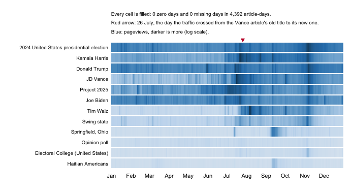

**Figure 1. The whole file, one cell per article-day.** Twelve articles down, 366 days across, shaded on a log scale — each step darker marks roughly ten times the readers, not a fixed number more — by how many people read each article on each day. A grid of cells is the form to use before any summary, because it holds every number in the file at once. Rows that differ by orders of magnitude sit side by side without one of them flattening the rest.

The picture is mostly pale. The median day — the one with as many busier days as quieter ones — sent 43,122 people to the article about the election itself. The peak sent 4,260,085, 99 times the median day. Attention does not build up over a campaign. It arrives.

| Article | % of the year’s views in its 10 busiest days | In its 30 busiest days | Days needed to reach half |
| --- | --- | --- | --- |
| Donald Trump | 27.0 | 41.5 | 53 |
| Kamala Harris | 39.3 | 60.1 | 18 |
| 2024 United States presidential election | 33.6 | 46.8 | 37 |
| Electoral College (United States) | 22.3 | 35.1 | 74 |
| Opinion poll | 6.9 | 16.0 | 132 |
| Springfield, Ohio | 63.2 | 78.9 | 7 |

**Half of everything read about Kamala Harris in 2024 arrived in 18 days.** For Donald Trump it took 53. That contrast is not a measure of importance. Trump was continuously famous throughout 2024, and Harris became the nominee overnight in July. **Concentration is measuring novelty**, which is the idea the rest of this brief turns on.

Notice that the topics behave differently from the people. The polling article took 132 days to reach half its annual traffic, against 18 for Harris. People spike; concepts trickle.

Now the ranking you wrote down.

| Person | Largest single day | Date | Median day | Peak ÷ median |
| --- | --- | --- | --- | --- |
| JD Vance | 5,120,129 | 15 July | 13,082 | 391× |
| Tim Walz | 3,811,244 | 6 August | 1,242 | 3067× |
| Donald Trump | 2,782,082 | 6 November | 43,000 | 65× |
| Kamala Harris | 2,532,334 | 22 July | 12,417 | 204× |

**The two running mates are first and second, and the two presidential nominees are third and fourth.** JD Vance’s 5,120,129 readers on 15 July and Tim Walz’s 3,811,244 on 6 August are both larger than Trump’s election-day peak of 2,782,082 and Harris’s 2,532,334. One of those tickets lost, and both running mates outdrew both nominees.

Hardly anybody writes that ranking down. The order most readers have in mind is an order of fame, or an order of how the election came out, and this table is neither. It ranks the four by how many strangers, on one day, needed to find out who they were. Being already known is exactly what keeps a number here low.

Measure each running mate against their own baseline before selection, rather than their median day for the year, and the point is sharper still. A sitting United States senator was running at 3,365 readers a day and a sitting governor at 475.[^5] **National political figures command almost no attention until somebody elevates them**, and the apparatus that makes a person famous is a single announcement rather than slow accumulation.

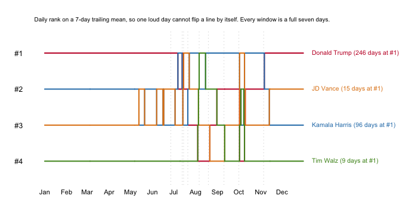

**Figure 2. Who the country was reading about, day by day.** The four people on the two national tickets, ranked against one another on a seven-day trailing mean — each day’s value is the average of that day and the six before it — so that one loud day cannot flip a line. Rank 1 is whoever drew the most readers. Both running mates appear from nowhere and cross both principals within days of being chosen.

| Period | Days Harris led | Days Trump led |
| --- | --- | --- |
| before 21 July | 8 | 194 |
| from 21 July | 107 | 57 |

**From 21 July, Harris drew more readers than Trump on 107 days out of 164.** Her ticket lost the election. If attention converted into votes, these two tables would be a forecast, and they are not one. They are a record of what surprised people, and a country looking something up is a country that does not already know.

Somebody has tested that directly. Yasseri and Bright (2016) modelled Wikipedia pageviews against results in the 2009 and 2014 European Parliament elections.[^6] They report that Wikipedia offers little insight into absolute vote outcomes, but does carry useful information about *changes*, in turnout and in a party’s share against last time. Their explanation is that voters look things up when they are weighing a change, which predicts the ranking above exactly.

The sharpest case in the file is not a person at all. On 10 September 2024, during the presidential debate, Donald Trump repeated a claim already circulating online that Haitian immigrants in Springfield, Ohio were eating their neighbours’ pets.[^7] The city’s police and its city manager had already said there were no credible reports of any such thing.[^8] **The claim was false. The attention was not.**

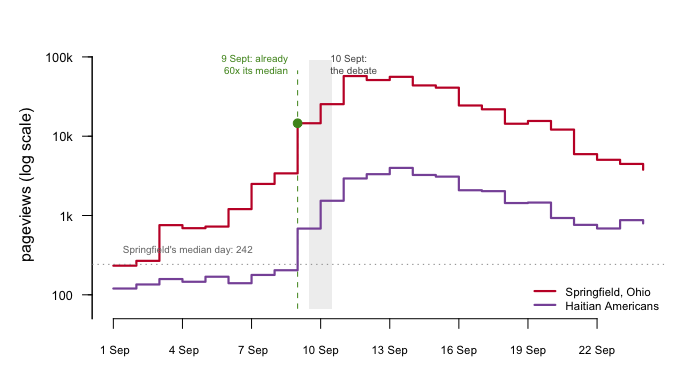

**Figure 3. Springfield, Ohio and its neighbours in the file, around the September debate.** Daily readership of the two articles the claim implicated, on a log scale because the two series sit far apart. The shaded column is debate day and the dashed line marks the day before it. The city drew 242 readers on a median day of 2024 and 57,339 on 11 September, 237 times its baseline.

**Read the figure one day earlier than you expected to.** On 9 September, before the debate, the article had already drawn 14,568 readers, 60 times its median. The debate did not start this. It was already moving, and the debate put it in front of a mass audience.

This is **agenda-setting** caught in the act, the effect McCombs and Shaw (1972) named from survey answers rather than from a record.[^9] Nothing told these readers what to think about Springfield. **It told them that Springfield was a thing to think about at all, and a false statement did that at least as efficiently as a true one would have.**

## What this brief cannot tell you

**It cannot measure exposure.** Far more people saw a headline about Springfield than went and looked it up, and this file counts only the fraction curious enough to act.

**It cannot measure belief or support.** Somebody who looked up Springfield may have been checking the claim, appalled by it, or looking for driving directions. Nothing here records what anyone thought before or afterwards.

**It has no demographics whatever.** No age, no location, no party, so no breakdown by group is possible. There is also no population this file is a sample of, so there is nothing to weight it to.

**Twelve articles is a list somebody wrote**, chosen by a person who already knew what 2024 contained. An article nobody thought to request casts no spike, and is indistinguishable here from an article nobody read.

**And the events file is deliberately incomplete.** That is what makes an unexplained spike a finding rather than an error, but it also means “no event” never means “no event happened.”

## What you should have learned

- Public attention is event-driven and extremely concentrated: half of a year’s reading about Kamala Harris arrived in 18 days, and the election article’s peak was 99 times its median day of 43,122.
- Concentration measures novelty, not importance: half of Trump’s traffic took 53 days, and the polling article 132.
- Being famous is not the same as being looked up: both running mates outdrew both nominees on their biggest days, 5,120,129 and 3,811,244 against 2,782,082 and 2,532,334.
- Attention is not a forecast. Harris led Trump in daily readers on 107 of the 164 days from 21 July, and her ticket lost.
- A false claim moved attention exactly as a true one would: Springfield, Ohio went from 242 readers on a median day to 57,339, and it had already started the day before the debate.

## Extensions

None of these is answered above, and every one can be answered by sorting or grouping the tables the Sources section hands over.

- `wiki_attention_2024.csv` has `date`, `article` and `views`. Join `campaign_events_2024.csv` on `date` and look at the week after each event. How long does attention last once something happens?
- `wiki_titles_2024.csv` carries `article`, `title` and `views`, with one article under two titles. Sum `views` by `title` and by month. What would a series that ignored the rename have reported for the spring?
- Group `wiki_attention_2024.csv` by `article` and compare each maximum `views` against its median. Does the size of a spike tell you anything about importance, or only about surprise?
- Sort `wiki_attention_2024.csv` by `views` and take the top fifty rows. How many distinct dates are in that list, and how much of the year’s total do they carry?

Two stretch ideas go past the spreadsheet. Add a thirteenth article’s 2024 counts from the same source and see whether it changes any conclusion above. And take one spike to a second source: search a newspaper archive for the same week and see whether the coverage arrives before the readers or after them.

## Sources

**Data**

- Wikimedia Foundation. *Pageviews API*, daily counts for English Wikipedia, 1 January to 31 December 2024, `user` agent filter, so human traffic only. Published under CC0, free and needing no key. https://wikimedia.org/api/rest_v1/#/Pageviews%20data. Requested one title at a time; where an article was renamed during the year, every title it held was requested and the daily counts summed. What a pageview is, and what is filtered out: https://meta.wikimedia.org/wiki/Research:Page_view. The CC0 dedication: https://dumps.wikimedia.org/other/analytics/.
- `campaign_events_2024.csv` — 9 dated events compiled by hand from the public record, kept separate from the pageview file so that it can serve as an independent yardstick.
- The three tables below hold those counts and the events list. Every number above is computed from them when this page is rendered.

**Method and prior work**

- McCombs, M. E. and Shaw, D. L. (1972). “The Agenda-Setting Function of Mass Media.” *Public Opinion Quarterly* 36(2): 176–187. https://doi.org/10.1086/267990 (the publisher’s address answered 403 to a script when last checked; the stable copy is https://www.jstor.org/stable/2747787)
- Mellon, J. (2014). “Internet Search Data and Issue Salience: The Properties of Google Trends as a Measure of Issue Salience.” *Journal of Elections, Public Opinion and Parties* 24(1): 45–72. https://doi.org/10.1080/17457289.2013.846346 (the publisher’s address answered 403 to a script when last checked)
- Yasseri, T. and Bright, J. (2016). “Wikipedia traffic data and electoral prediction: towards theoretically informed models.” *EPJ Data Science* 5: 22. https://doi.org/10.1140/epjds/s13688-016-0083-3; open copy at https://arxiv.org/abs/1505.01818

**The data itself**

Every figure above is drawn from these tables. They are plain CSV, they open in a spreadsheet, and they are yours to take further.

`campaign_events_2024.csv`, `wiki_attention_2024.csv`, `wiki_titles_2024.csv`

Rebuild this data yourself, with an AI assistant

[output not shown]

[^1]: Trump named Vance his running mate on 15 July 2024, the first day of the Republican convention: https://www.cnbc.com/2024/07/15/donald-trump-vp-announcement.html.
[^2]: How a pageview is defined and which requests are filtered out: https://meta.wikimedia.org/wiki/Research:Page_view. The Foundation’s statement that all of its analytics datasets are released under CC0: https://dumps.wikimedia.org/other/analytics/.
[^3]: https://www.npr.org/2024/07/21/nx-s1-5024253/biden-drops-out-2024-presidential-election.
[^4]: The move is recorded in the article’s log: https://en.wikipedia.org/w/index.php?title=Special:Log&type=move&page=J._D._Vance.
[^5]: Harris named Walz her running mate on 6 August 2024: https://www.npr.org/2024/08/06/nx-s1-5057604/tim-walz-harris-vice-president.
[^6]: Taha Yasseri and Jonathan Bright, “Wikipedia traffic data and electoral prediction: towards theoretically informed models,” *EPJ Data Science* 5 (2016): 22, https://doi.org/10.1140/epjds/s13688-016-0083-3; an open copy is at https://arxiv.org/abs/1505.01818.
[^7]: The debate transcript: https://www.presidency.ucsb.edu/documents/presidential-debate-philadelphia-pennsylvania.
[^8]: Springfield’s statements, as reported by NBC News: https://www.nbcnews.com/tech/misinformation/jd-vance-ohio-police-no-reports-haitian-immigrants-harming-pets-rcna170271.
[^9]: Maxwell E. McCombs and Donald L. Shaw, “The Agenda-Setting Function of Mass Media,” *Public Opinion Quarterly* 36, no. 2 (1972): 176–187, https://www.jstor.org/stable/2747787.